# DATA 621 HW 1

Last edited September 27, 2023

# **Business Analytics and Data Mining**

## Homework #1 Assignment Requirements

### **Overview**

In this homework assignment, you will explore, analyze and model a data set containing approximately 2200 records. Each record represents a professional baseball team from the years 1871 to 2006 inclusive. Each record has the performance of the team for the given year, with all of the statistics adjusted to match the performance of a 162 game season.

Your objective is to build a multiple linear regression model on the training data to predict the number of wins for the team. You can only use the variables given to you (or variables that you derive from the variables provided).

Below is a short description of the variables of interest in the data set:

[output not shown]

### **Deliverable:**

- A write-up submitted in PDF format. Your write-up should have four sections. Each one is described below. You may assume you are addressing me as a fellow data scientist, so do not need to shy away from technical details.
- Assigned predictions (the number of wins for the team) for the evaluation data set.
- Include your R statistical programming code in an Appendix.

### **Write Up:**

1. **DATA EXPLORATION (25 Points)** Describe the size and the variables in the moneyball training data set. Consider that too much detail will cause a manager to lose interest while too little detail will make the manager consider that you aren’t doing your job. Some suggestions are given below. Please do NOT treat this as a check list of things to do to complete the assignment. You should have your own thoughts on what to tell the boss. These are just ideas.
1. Mean / Standard Deviation / Median
2. Bar Chart or Box Plot of the data
3. Is the data correlated to the target variable (or to other variables?)
4. Are any of the variables missing and need to be imputed “fixed”?
2. **DATA PREPARATION (25 Points)** Describe how you have transformed the data by changing the original variables or creating new variables. If you did transform the data or create new variables, discuss why you did this. Here are some possible transformations.
1. Fix missing values (maybe with a Mean or Median value)
2. Create flags to suggest if a variable was missing
3. Transform data by putting it into buckets
4. Mathematical transforms such as log or square root (or use Box-Cox)
5. Combine variables (such as ratios or adding or multiplying) to create new variables
3. **BUILD MODELS (25 Points)** Using the training data set, build at least three different multiple linear regression models, using different variables (or the same variables with different transformations). Since we have not yet covered automated variable selection methods, you should select the variables manually (unless you previously learned Forward or Stepwise selection, etc.). Since you manually selected a variable for inclusion into the model or exclusion into the model, indicate why this was done. Discuss the coefficients in the models, do they make sense? For example, if a team hits a lot of Home Runs, it would be reasonably expected that such a team would win more games. However, if the coefficient is negative (suggesting that the team would lose more games), then that needs to be discussed. Are you keeping the model even though it is counter intuitive? Why? The boss needs to know.
4. **SELECT MODELS (25 Points)** Decide on the criteria for selecting the best multiple linear regression model. Will you select a model with slightly worse performance if it makes more sense or is more parsimonious? Discuss why you selected your model. For the multiple linear regression model, will you use a metric such as Adjusted R2 , RMSE, etc.? Be sure to explain how you can make inferences from the model, discuss multi-collinearity issues (if any), and discuss other relevant model output. Using the training data set, evaluate the multiple linear regression model based on (a) mean squared error, (b) R2, (c) F-statistic, and (d) residual plots. Make predictions using the evaluation data set.

## **Evaluation**

### **Load the data**

```r
git_url<-
  "https://raw.githubusercontent.com/melbow2424/Data621_HW1/main/"

df_train <-
  read.csv(paste0(git_url,"moneyball-training-data.csv"))

df_evaluation <-
  read.csv(paste0(git_url,"moneyball-evaluation-data.csv"))
```

### 1. Data Exploration**

```r
print(skim(df_train))
```

```
## ── Data Summary ────────────────────────
##                            Values
## Name                       df_train
## Number of rows             2276
## Number of columns          17
## _______________________
## Column type frequency:
##   numeric                  17
## ________________________
## Group variables            None
##
## ── Variable type: numeric ──────────────────────────────────────────────────────
##    skim_variable    n_missing complete_rate   mean     sd   p0    p25   p50
##  1 INDEX                    0        1      1268.   736.     1  631.  1270.
##  2 TARGET_WINS              0        1        80.8   15.8    0   71     82
```

[output cut: 33 more lines]

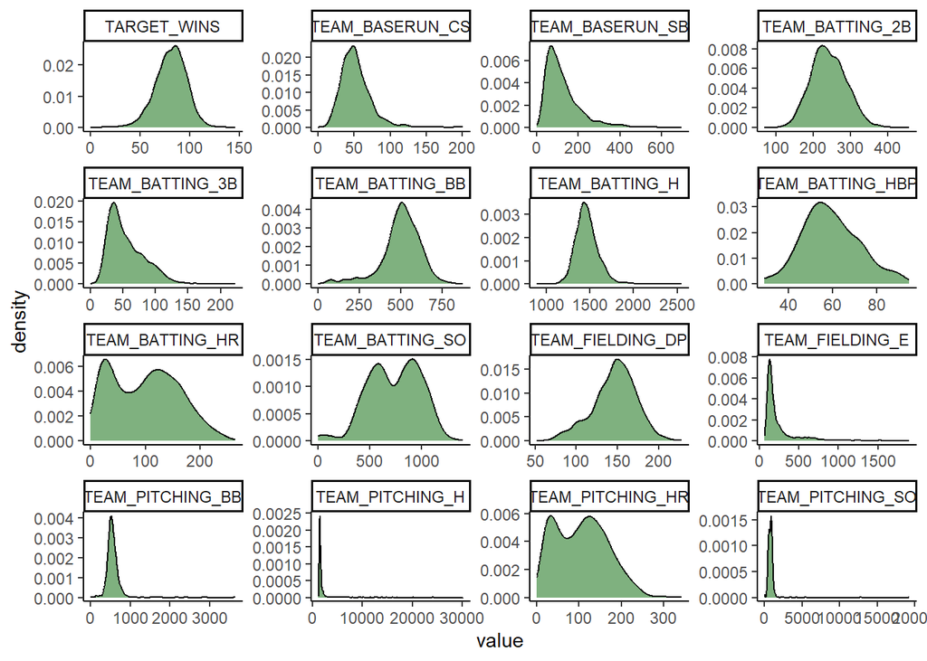

```r
df_train %>%
  gather(variable, value, TARGET_WINS: TEAM_FIELDING_DP)%>% #pivot longer to plot all variables
  ggplot(.,aes(x=value)) + #plotting every variable
  geom_density(fill = "darkgreen", alpha = 0.5) +
  facet_wrap(~ variable, scales = "free", ncol = 4) +
  theme_classic()
```

#### **Get the Means of columns in Data**

```r
train_means<-sapply(df_train, function(x) round(mean(x, na.rm = TRUE)))
train_means
```

```
##            INDEX      TARGET_WINS   TEAM_BATTING_H  TEAM_BATTING_2B
##             1268               81             1469              241
##  TEAM_BATTING_3B  TEAM_BATTING_HR  TEAM_BATTING_BB  TEAM_BATTING_SO
##               55              100              502              736
##  TEAM_BASERUN_SB  TEAM_BASERUN_CS TEAM_BATTING_HBP  TEAM_PITCHING_H
##              125               53               59             1779
## TEAM_PITCHING_HR TEAM_PITCHING_BB TEAM_PITCHING_SO  TEAM_FIELDING_E
##              106              553              818              246
## TEAM_FIELDING_DP
##              146
```

```r
eval_means<-sapply(df_evaluation, function(x) round(mean(x, na.rm = TRUE)))
eval_means
```

```
##            INDEX   TEAM_BATTING_H  TEAM_BATTING_2B  TEAM_BATTING_3B
##             1264             1469              241               56
##  TEAM_BATTING_HR  TEAM_BATTING_BB  TEAM_BATTING_SO  TEAM_BASERUN_SB
##               96              499              709              124
##  TEAM_BASERUN_CS TEAM_BATTING_HBP  TEAM_PITCHING_H TEAM_PITCHING_HR
##               52               62             1813              102
## TEAM_PITCHING_BB TEAM_PITCHING_SO  TEAM_FIELDING_E TEAM_FIELDING_DP
##              552              800              250              146
```

#### **Get the Medians of columns in data**

```r
train_medians<-sapply(df_train, function(x) round(median(x, na.rm = TRUE)))
train_medians
```

```
##            INDEX      TARGET_WINS   TEAM_BATTING_H  TEAM_BATTING_2B
##             1270               82             1454              238
##  TEAM_BATTING_3B  TEAM_BATTING_HR  TEAM_BATTING_BB  TEAM_BATTING_SO
##               47              102              512              750
##  TEAM_BASERUN_SB  TEAM_BASERUN_CS TEAM_BATTING_HBP  TEAM_PITCHING_H
##              101               49               58             1518
## TEAM_PITCHING_HR TEAM_PITCHING_BB TEAM_PITCHING_SO  TEAM_FIELDING_E
##              107              536              814              159
## TEAM_FIELDING_DP
##              149
```

```r
eval_medians<-sapply(df_evaluation, function(x) round(median(x, na.rm = TRUE)))
eval_medians
```

```
##            INDEX   TEAM_BATTING_H  TEAM_BATTING_2B  TEAM_BATTING_3B
##             1249             1455              239               52
##  TEAM_BATTING_HR  TEAM_BATTING_BB  TEAM_BATTING_SO  TEAM_BASERUN_SB
##              101              509              686               92
##  TEAM_BASERUN_CS TEAM_BATTING_HBP  TEAM_PITCHING_H TEAM_PITCHING_HR
##               50               62             1515              104
## TEAM_PITCHING_BB TEAM_PITCHING_SO  TEAM_FIELDING_E TEAM_FIELDING_DP
##              526              745              163              148
```

#### **Replace NA values in columns with their respective Mean**

Made new copies of Train and Evaluation datasets, with imputed means.

```r
# Replace NA values in 'column_name' with 'mean'
df_train_mn <- df_train %>%
  mutate(TEAM_BATTING_SO =
           ifelse(is.na(TEAM_BATTING_SO),
                  train_means[8],TEAM_BATTING_SO))%>%
  mutate(TEAM_BASERUN_SB =
           ifelse(is.na(TEAM_BASERUN_SB),
                  train_means[9], TEAM_BASERUN_SB))%>%
  mutate(TEAM_BASERUN_CS =
           ifelse(is.na(TEAM_BASERUN_CS),
                  train_means[10], TEAM_BASERUN_CS))%>%
  mutate(TEAM_BATTING_HBP =
           ifelse(is.na(TEAM_BATTING_HBP),
                  train_means[11],TEAM_BATTING_HBP))%>%
  mutate(TEAM_PITCHING_SO =
           ifelse(is.na(TEAM_PITCHING_SO),
                  train_means[15], TEAM_PITCHING_SO))%>%
  mutate(TEAM_FIELDING_DP =
           ifelse(is.na(TEAM_FIELDING_DP),
                  train_means[17], TEAM_FIELDING_DP))
```

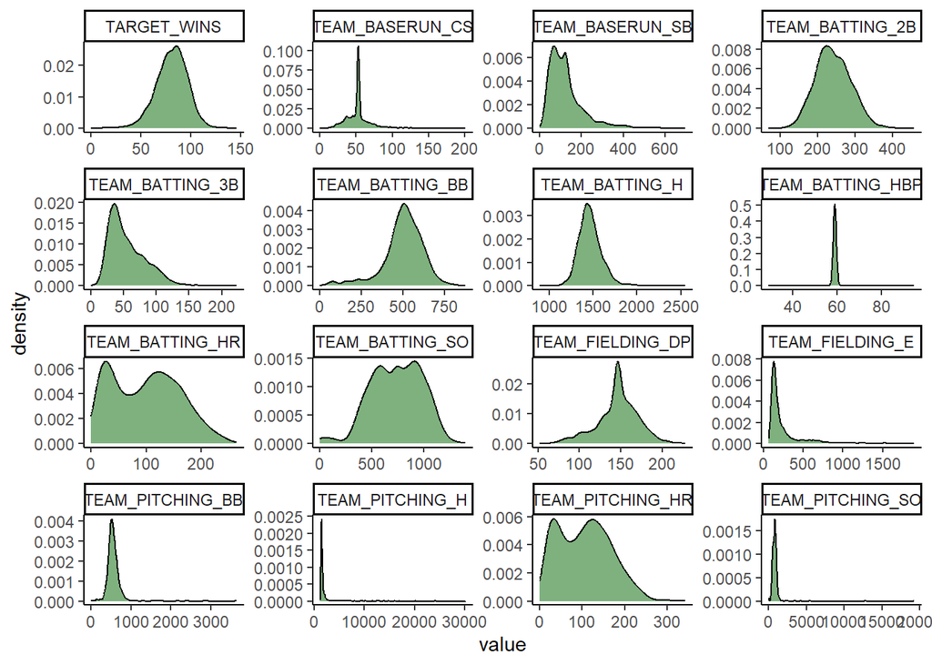

```r
df_train_mn %>%
  gather(variable, value, TARGET_WINS: TEAM_FIELDING_DP)%>% #pivot longer to plot all variables
  ggplot(.,aes(x=value)) + #plotting every variable
  geom_density(fill = "darkgreen", alpha = 0.5) +
  facet_wrap(~ variable, scales = "free", ncol = 4) +
  theme_classic()
```

```r
df_evaluation_mn <- df_evaluation %>%
  mutate(TEAM_BATTING_SO =
           ifelse(is.na(TEAM_BATTING_SO),
                  eval_means[8],TEAM_BATTING_SO))%>%
  mutate(TEAM_BASERUN_SB =
           ifelse(is.na(TEAM_BASERUN_SB),
                  eval_means[9], TEAM_BASERUN_SB))%>%
  mutate(TEAM_BASERUN_CS =
           ifelse(is.na(TEAM_BASERUN_CS),
                  eval_means[10], TEAM_BASERUN_CS))%>%
  mutate(TEAM_BATTING_HBP =
           ifelse(is.na(TEAM_BATTING_HBP),
                  eval_means[11],TEAM_BATTING_HBP))%>%
  mutate(TEAM_PITCHING_SO =
           ifelse(is.na(TEAM_PITCHING_SO),
                  eval_means[15], TEAM_PITCHING_SO))%>%
  mutate(TEAM_FIELDING_DP =
           ifelse(is.na(TEAM_FIELDING_DP),
                  eval_means[17], TEAM_FIELDING_DP))
```

#### **Replace NA values with their respective Medians**

Made new copies of Train and Evaluation datasets, with imputed median.

```r
# Replace NA values in 'column_name' with 'median'
df_train_md <- df_train %>%
  mutate(TEAM_BATTING_SO =
           ifelse(is.na(TEAM_BATTING_SO),
                  train_medians[8],TEAM_BATTING_SO))%>%
  mutate(TEAM_BASERUN_SB =
           ifelse(is.na(TEAM_BASERUN_SB),
                  train_medians[9], TEAM_BASERUN_SB))%>%
  mutate(TEAM_BASERUN_CS =
           ifelse(is.na(TEAM_BASERUN_CS),
                  train_medians[10], TEAM_BASERUN_CS))%>%
  mutate(TEAM_BATTING_HBP =
           ifelse(is.na(TEAM_BATTING_HBP),
                  train_medians[11],TEAM_BATTING_HBP))%>%
  mutate(TEAM_PITCHING_SO =
           ifelse(is.na(TEAM_PITCHING_SO),
                  train_medians[15], TEAM_PITCHING_SO))%>%
  mutate(TEAM_FIELDING_DP =
           ifelse(is.na(TEAM_FIELDING_DP),
                  train_medians[17], TEAM_FIELDING_DP))
```

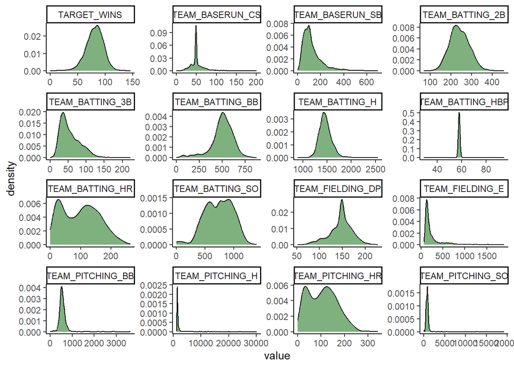

```r
df_train_md %>%
  gather(variable, value, TARGET_WINS: TEAM_FIELDING_DP)%>% #pivot longer to plot all variables
  ggplot(.,aes(x=value)) + #plotting every variable
  geom_density(fill = "darkgreen", alpha = 0.5) +
  facet_wrap(~ variable, scales = "free", ncol = 4) +
  theme_classic()
```

```r
df_evaluation_md <- df_evaluation %>%
  mutate(TEAM_BATTING_SO =
           ifelse(is.na(TEAM_BATTING_SO),
                  eval_medians[8],TEAM_BATTING_SO))%>%
  mutate(TEAM_BASERUN_SB =
           ifelse(is.na(TEAM_BASERUN_SB),
                  eval_medians[9], TEAM_BASERUN_SB))%>%
  mutate(TEAM_BASERUN_CS =
           ifelse(is.na(TEAM_BASERUN_CS),
                  eval_medians[10], TEAM_BASERUN_CS))%>%
  mutate(TEAM_BATTING_HBP =
           ifelse(is.na(TEAM_BATTING_HBP),
                  eval_medians[11],TEAM_BATTING_HBP))%>%
  mutate(TEAM_PITCHING_SO =
           ifelse(is.na(TEAM_PITCHING_SO),
                  eval_medians[15], TEAM_PITCHING_SO))%>%
  mutate(TEAM_FIELDING_DP =
           ifelse(is.na(TEAM_FIELDING_DP),
                  eval_medians[17], TEAM_FIELDING_DP))
```

#### **Replace NA values with 0**

Made new copies of Train and Evaluation datasets, with imputed zeros.

```r
df_train_0 <- df_train %>%
  replace_na(list(
    INDEX = 0,
    TARGET_WINS = 0,
    TEAM_BATTING_H = 0,
    TEAM_BATTING_2B = 0,
    TEAM_BATTING_3B = 0,
    TEAM_BATTING_HR = 0,
    TEAM_BATTING_BB = 0,
    TEAM_BATTING_SO = 0,
    TEAM_BASERUN_SB = 0,
    TEAM_BASERUN_CS = 0,
    TEAM_BATTING_HBP = 0,
    TEAM_PITCHING_H = 0,
    TEAM_PITCHING_HR = 0,
    TEAM_PITCHING_BB = 0,
    TEAM_PITCHING_SO = 0,
    TEAM_FIELDING_E = 0,
    TEAM_FIELDING_DP = 0
  ))
```

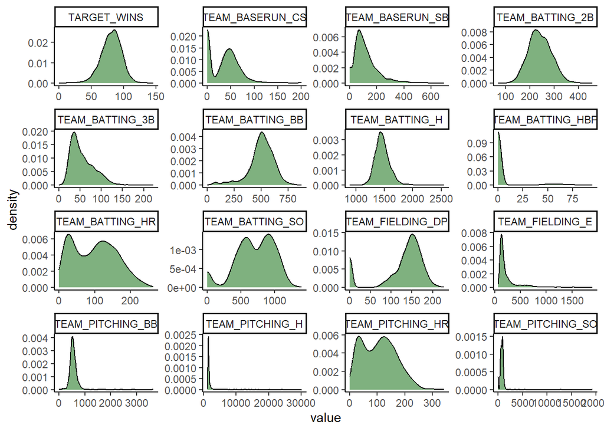

```r
df_train_0 %>%
  gather(variable, value, TARGET_WINS: TEAM_FIELDING_DP)%>% #pivot longer to plot all variables
  ggplot(.,aes(x=value)) + #plotting every variable
  geom_density(fill = "darkgreen", alpha = 0.5) +
  facet_wrap(~ variable, scales = "free", ncol = 4) +
  theme_classic()
```

##### Observations after imputation with the zero

- Imputation with zero is a poor choice as it introduces strong peaks to the left of the distribution of many variables such as **TEAM_FIELDING_DP**

```r
df_evaluation_0 <- df_evaluation %>%
  replace_na(list(
    INDEX = 0,
    TARGET_WINS = 0,
    TEAM_BATTING_H = 0,
    TEAM_BATTING_2B = 0,
    TEAM_BATTING_3B = 0,
    TEAM_BATTING_HR = 0,
    TEAM_BATTING_BB = 0,
    TEAM_BATTING_SO = 0,
    TEAM_BASERUN_SB = 0,
    TEAM_BASERUN_CS = 0,
    TEAM_BATTING_HBP = 0,
    TEAM_PITCHING_H = 0,
    TEAM_PITCHING_HR = 0,
    TEAM_PITCHING_BB = 0,
    TEAM_PITCHING_SO = 0,
    TEAM_FIELDING_E = 0,
    TEAM_FIELDING_DP = 0
  ))
```

### Remove all rows with NA’s

```r
df_train_rm<- na.omit(df_train)
df_evaluation_rm<- na.omit(df_evaluation)
```

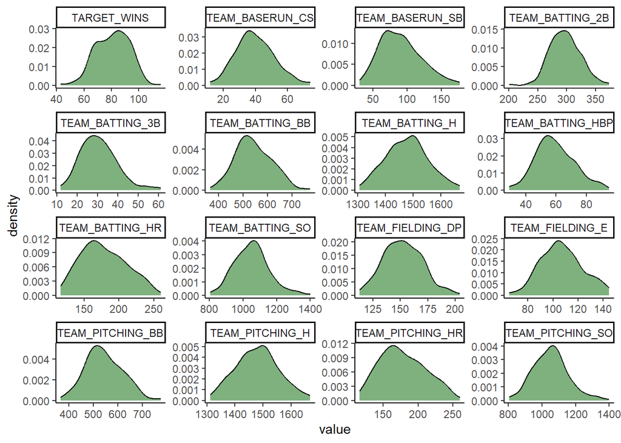

```r
df_train_rm %>%
  gather(variable, value, TARGET_WINS: TEAM_FIELDING_DP)%>% #pivot longer to plot all variables
  ggplot(.,aes(x=value)) + #plotting every variable
  geom_density(fill = "darkgreen", alpha = 0.5) +
  facet_wrap(~ variable, scales = "free", ncol = 4) +
  theme_classic()
```

##### Observations after removal of missing data * Although removal of missing data resolves the distributions of many variables, the sample size is reduced to under 10% of the original dataset from 2276 observations to only 191 observations in the training dataset

```r
#print(skim(df_train_mn))
```

```r
#print(skim(df_train_md))
```

```r
#print(skim(df_train_0))
```

#### Correlation with response variable

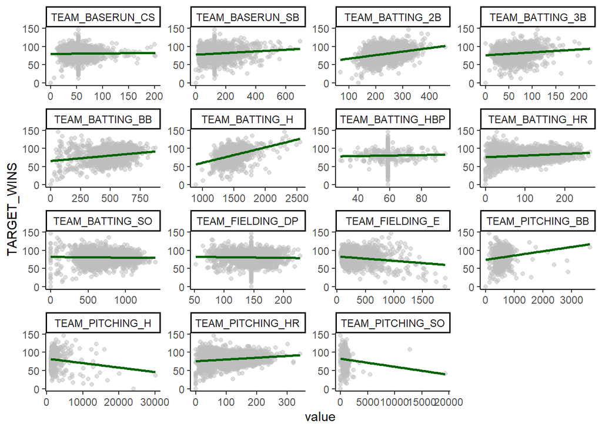

```r
df_train_mn %>%
  gather(variable, value, TEAM_BATTING_H: TEAM_FIELDING_DP)%>% #pivot longer to plot all variables
  ggplot(.,aes(x=value, y=TARGET_WINS)) + #plotting every variable
  geom_point(color = "grey", alpha = 0.5) +
  geom_smooth(method = "lm", se = FALSE, color = "darkgreen") +
  facet_wrap(~ variable, scales = "free", ncol = 4) +
  theme_classic()
```

```r
# df_train_mn %>%
#  select(-INDEX) %>%
#   cor(.,) %>%
#   corrplot(.,method = "ellipse", type = "lower", diag = FALSE)
```

## **Models**

#Test Model

```r
model_initial <- lm(TARGET_WINS ~ TEAM_BATTING_H+TEAM_BATTING_2B +TEAM_BATTING_3B+TEAM_BATTING_HR+TEAM_BATTING_BB+TEAM_BATTING_SO+
TEAM_BASERUN_SB+ TEAM_BASERUN_CS + TEAM_BATTING_HBP +TEAM_PITCHING_H+ TEAM_PITCHING_HR+TEAM_PITCHING_BB+TEAM_PITCHING_SO+TEAM_FIELDING_E+ TEAM_FIELDING_DP, data = df_train)

summary(model_initial)
```

```
##
## Call:
## lm(formula = TARGET_WINS ~ TEAM_BATTING_H + TEAM_BATTING_2B +
##     TEAM_BATTING_3B + TEAM_BATTING_HR + TEAM_BATTING_BB + TEAM_BATTING_SO +
##     TEAM_BASERUN_SB + TEAM_BASERUN_CS + TEAM_BATTING_HBP + TEAM_PITCHING_H +
##     TEAM_PITCHING_HR + TEAM_PITCHING_BB + TEAM_PITCHING_SO +
##     TEAM_FIELDING_E + TEAM_FIELDING_DP, data = df_train)
##
## Residuals:
##      Min       1Q   Median       3Q      Max
## -19.8708  -5.6564  -0.0599   5.2545  22.9274
##
## Coefficients:
##                  Estimate Std. Error t value Pr(>|t|)
## (Intercept)      60.28826   19.67842   3.064  0.00253 **
## TEAM_BATTING_H    1.91348    2.76139   0.693  0.48927
## TEAM_BATTING_2B   0.02639    0.03029   0.871  0.38484
## TEAM_BATTING_3B  -0.10118    0.07751  -1.305  0.19348
## TEAM_BATTING_HR  -4.84371   10.50851  -0.461  0.64542
## TEAM_BATTING_BB  -4.45969    3.63624  -1.226  0.22167
## TEAM_BATTING_SO   0.34196    2.59876   0.132  0.89546
## TEAM_BASERUN_SB   0.03304    0.02867   1.152  0.25071
## TEAM_BASERUN_CS  -0.01104    0.07143  -0.155  0.87730
## TEAM_BATTING_HBP  0.08247    0.04960   1.663  0.09815 .
## TEAM_PITCHING_H  -1.89096    2.76095  -0.685  0.49432
## TEAM_PITCHING_HR  4.93043   10.50664   0.469  0.63946
## TEAM_PITCHING_BB  4.51089    3.63372   1.241  0.21612
## TEAM_PITCHING_SO -0.37364    2.59705  -0.144  0.88577
## TEAM_FIELDING_E  -0.17204    0.04140  -4.155 5.08e-05 ***
## TEAM_FIELDING_DP -0.10819    0.03654  -2.961  0.00349 **
## ---
## Signif. codes:  0 '***' 0.001 '**' 0.01 '*' 0.05 '.' 0.1 ' ' 1
##
## Residual standard error: 8.467 on 175 degrees of freedom
##   (2085 observations deleted due to missingness)
## Multiple R-squared:  0.5501, Adjusted R-squared:  0.5116
## F-statistic: 14.27 on 15 and 175 DF,  p-value: < 2.2e-16
```

### DIAGNOSTIC PLOTS FOR THE FULL MODEL ON ORIGINAL TRAINING DATA

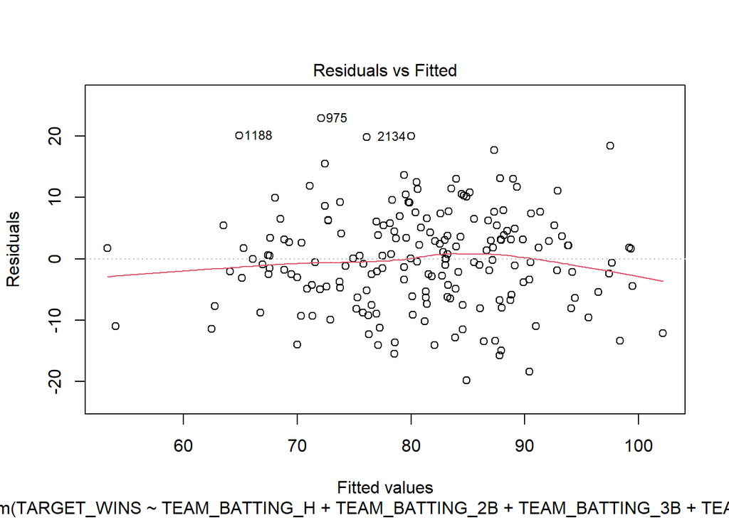

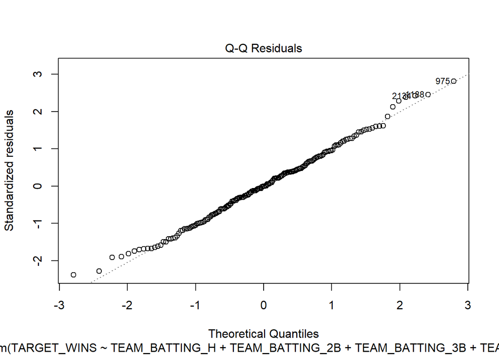

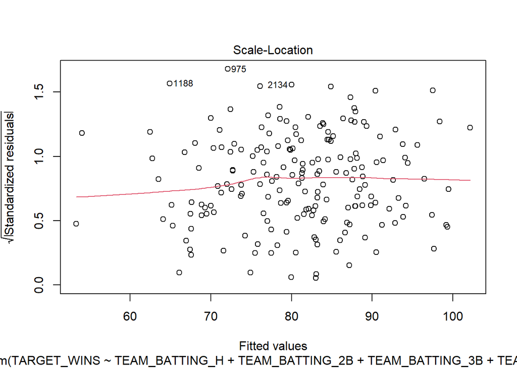

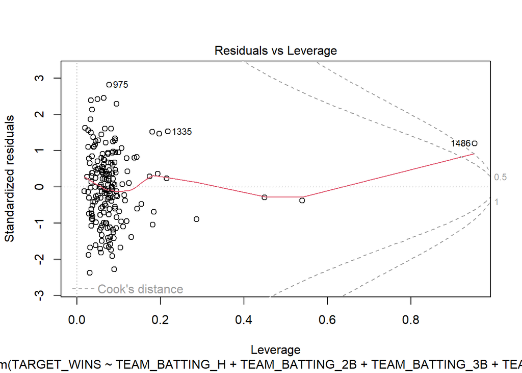

```r
plot(model_initial)
```

To determine how to handle missing variables, we created four different datasets. We imputed missing values with the mean, median, and zero, and also removed the missing values altogether.

Afterwards, we constructed linear models using these four datasets to determine which model had the best adjusted R-squared value.

```r
# Fit a multiple linear regression model using lm with variables imputed:mean
model_mn <- lm(TARGET_WINS ~ ., data = df_train_mn)

# Summary of the regression model
summary(model_mn)$adj.r.squared
```

```
## [1] 0.3148773
```

```r
# Fit a multiple linear regression model using lm with variables imputed:median
model_md <- lm(TARGET_WINS ~ ., data = df_train_md)

# Summary of the regression model
summary(model_md)$adj.r.squared
```

```
## [1] 0.3111035
```

```r
# Fit a multiple linear regression model using lm with variables imputed:zero
model_0 <- lm(TARGET_WINS ~ ., data = df_train_0)

# Summary of the regression model
summary(model_0)$adj.r.squared
```

```
## [1] 0.2942964
```

```r
# Fit a multiple linear regression model using lm with variables: removed
model_rm <- lm(TARGET_WINS ~ ., data = df_train_rm)

# Summary of the regression model
summary(model_rm)$adj.r.squared
```

```
## [1] 0.5089872
```

By removing the missing variables, we observed a more favorable adjusted R-squared value, indicating an improvement. Therefore, the missing variables have been successfully removed.

Next, we checked the Pearson correlation values of the chosen model to identify which independent variables correlate best with our dependent variable (TARGET_WINS).

[output not shown]

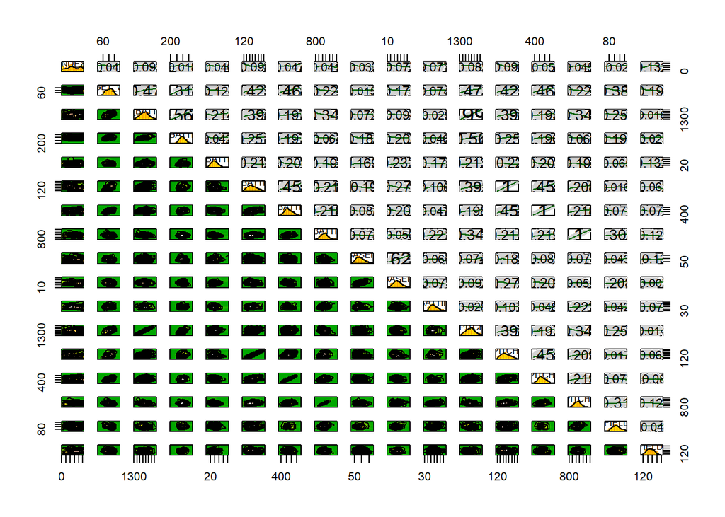

```r
# Create a subset that includes all columns
all_columns_subset <- df_train_rm[, ]

kdepairs(all_columns_subset)
```

When examining the correlations, we observed some multicollinearity among the following variables:

TEAM_BATTING_H and TEAM_PITCHING_H TEAM_BATTING_HR and TEAM_PITCHING_HR TEAM_BATTING_BB and TEAM_PITCHING_BB TEAM_BATTING_SO and TEAM_PITCHING_SO

Due to the high correlation between these variables, we made the decision to combine them into single variables through addition.

```r
#Also tried to minus it as well. Did not work.(delete later)
#Creating new data set with combined correlated variables and removed correlated variables
df_train_with_combo <- df_train_rm %>%
  mutate(team_H = TEAM_BATTING_H + TEAM_PITCHING_H,
         team_HR = TEAM_BATTING_HR + TEAM_PITCHING_HR,
         team_BB = TEAM_BATTING_BB + TEAM_PITCHING_BB,
         team_SO = TEAM_BATTING_SO + TEAM_PITCHING_SO)%>%
  select(-TEAM_BATTING_H, -TEAM_PITCHING_H, -TEAM_BATTING_HR, -TEAM_PITCHING_HR, -TEAM_BATTING_BB,-TEAM_PITCHING_BB,
         -TEAM_BATTING_SO,- TEAM_PITCHING_SO)
```

Testing this new data set

```r
# Fit a multiple linear regression model using lm with variables: removed
model_combo <- lm(TARGET_WINS ~ ., data = df_train_with_combo)

# Summary of the regression model
summary(model_combo)$adj.r.squared
```

```
## [1] 0.5146459
```

It led to a slight improvement in the model from 0.5089872.

Let’s redo the correlations to select the most highly correlated variables.

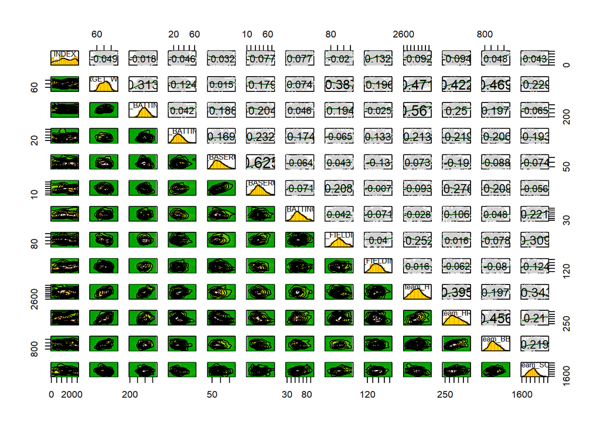

```r
# Create a subset that includes all columns
all_columns_subset <- df_train_with_combo[, ]

kdepairs(all_columns_subset)
```

After identifying the highest correlation values and manually reviewing the variables, the best model produced without any transformation is as follows:

```r
model <- lm(TARGET_WINS ~ team_H + team_BB + TEAM_FIELDING_E +TEAM_FIELDING_DP+ team_SO+ team_HR+ TEAM_BATTING_HBP+ TEAM_BATTING_3B +TEAM_BASERUN_SB, data = df_train_with_combo)

summary(model)
```

```
##
## Call:
## lm(formula = TARGET_WINS ~ team_H + team_BB + TEAM_FIELDING_E +
##     TEAM_FIELDING_DP + team_SO + team_HR + TEAM_BATTING_HBP +
##     TEAM_BATTING_3B + TEAM_BASERUN_SB, data = df_train_with_combo)
##
## Residuals:
##      Min       1Q   Median       3Q      Max
## -20.7465  -5.6877   0.0659   4.8657  22.5430
##
## Coefficients:
##                   Estimate Std. Error t value Pr(>|t|)
## (Intercept)      57.596453  19.129457   3.011 0.002977 **
## team_H            0.014172   0.005371   2.639 0.009051 **
## team_BB           0.027383   0.004732   5.787 3.10e-08 ***
## TEAM_FIELDING_E  -0.177012   0.039717  -4.457 1.45e-05 ***
## TEAM_FIELDING_DP -0.106207   0.035731  -2.972 0.003357 **
## team_SO          -0.015415   0.003634  -4.241 3.54e-05 ***
## team_HR           0.043523   0.012576   3.461 0.000672 ***
## TEAM_BATTING_HBP  0.079448   0.048856   1.626 0.105652
## TEAM_BATTING_3B  -0.112980   0.075511  -1.496 0.136345
## TEAM_BASERUN_SB   0.026802   0.021510   1.246 0.214360
## ---
## Signif. codes:  0 '***' 0.001 '**' 0.01 '*' 0.05 '.' 0.1 ' ' 1
##
## Residual standard error: 8.388 on 181 degrees of freedom
## Multiple R-squared:  0.5433, Adjusted R-squared:  0.5206
## F-statistic: 23.93 on 9 and 181 DF,  p-value: < 2.2e-16
```

### DIAGNOSTIC PLOTS OF FINAL MODEL

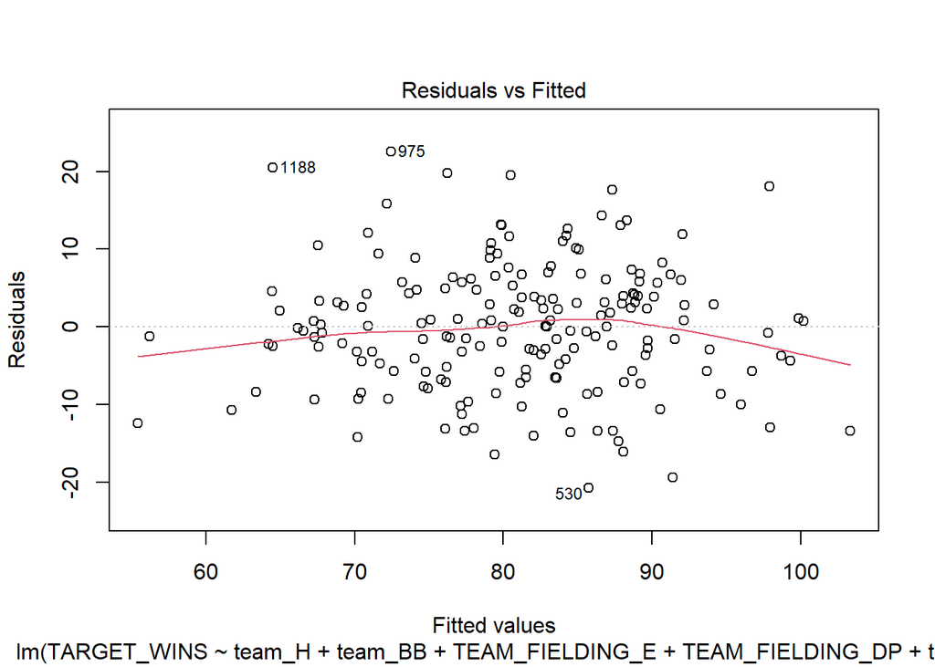

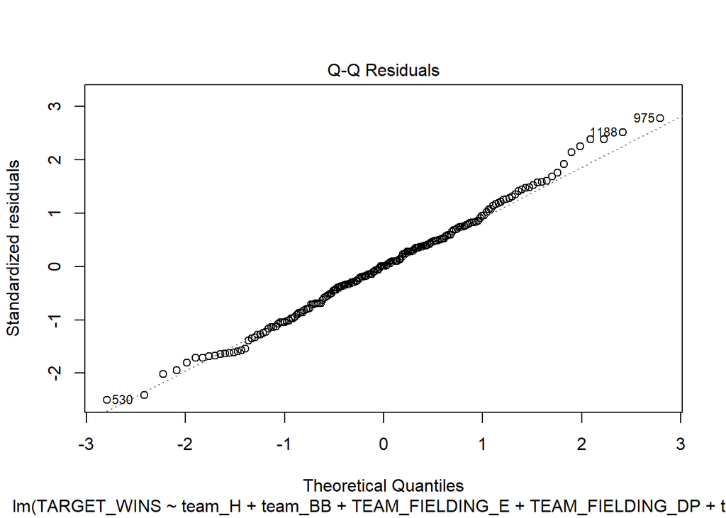

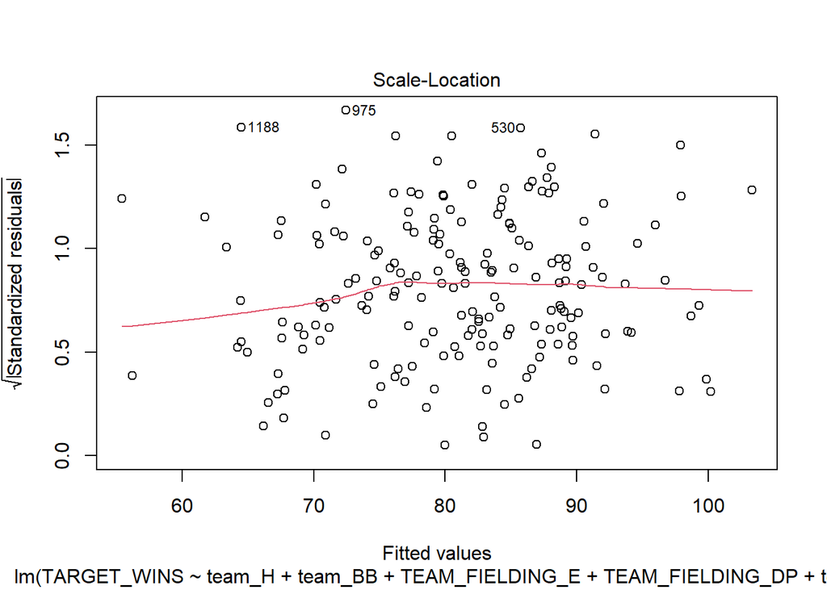

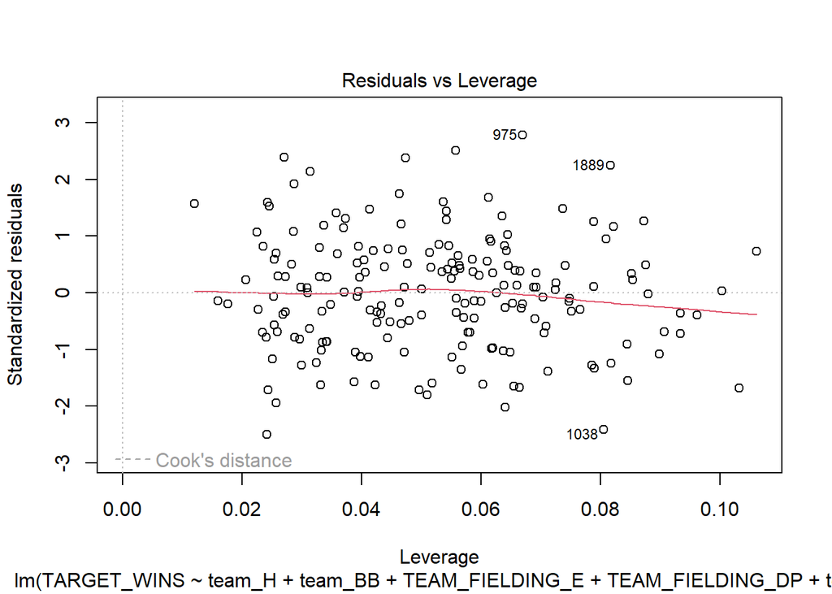

```r
plot(model)
```

### BIVARIATE PLOTS OF WINS BY SIGNIFICANT PREDICTORS

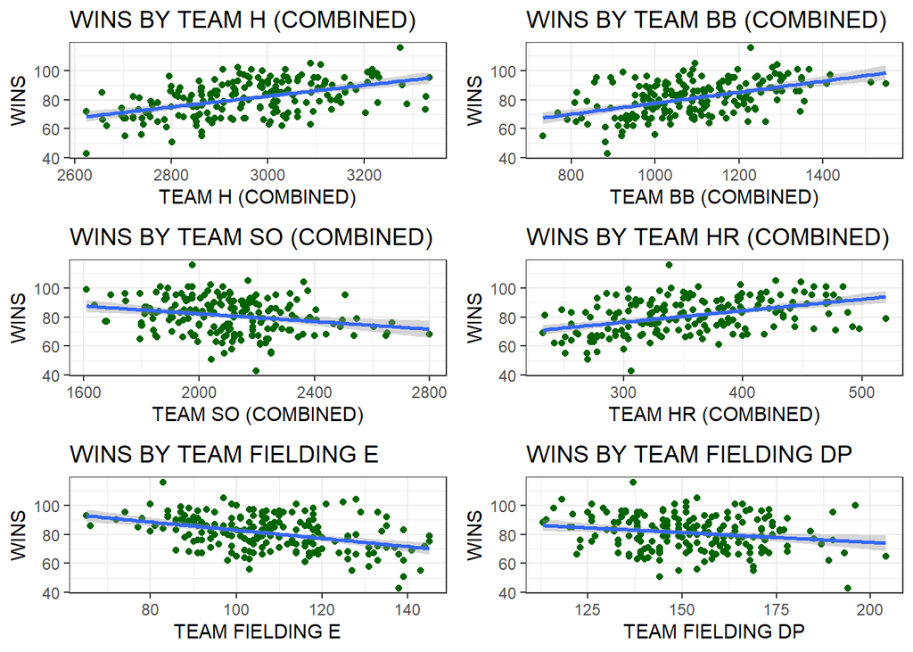

```r
p1 <- df_train_with_combo %>%
  ggplot(aes(y=TARGET_WINS, x=team_H)) +
  geom_point(color="darkgreen") +
  geom_smooth(method = "lm", se=TRUE) +
  labs(title = "WINS BY TEAM H (COMBINED)",
       x="TEAM H (COMBINED)", y="WINS") +
  theme_bw()

p2 <- df_train_with_combo %>%
  ggplot(aes(y=TARGET_WINS, x=team_BB)) +
  geom_point(color="darkgreen") +
  geom_smooth(method = "lm", se=TRUE) +
  labs(title = "WINS BY TEAM BB (COMBINED)",
       x="TEAM BB (COMBINED)", y="WINS") +
  theme_bw()

p3 <- df_train_with_combo %>%
  ggplot(aes(y=TARGET_WINS, x=team_SO)) +
  geom_point(color="darkgreen") +
  geom_smooth(method = "lm", se=TRUE) +
  labs(title = "WINS BY TEAM SO (COMBINED)",
       x="TEAM SO (COMBINED)", y="WINS") +
  theme_bw()

p4 <- df_train_with_combo %>%
  ggplot(aes(y=TARGET_WINS, x=team_HR)) +
  geom_point(color="darkgreen") +
  geom_smooth(method = "lm", se=TRUE) +
  labs(title = "WINS BY TEAM HR (COMBINED)",
       x="TEAM HR (COMBINED)", y="WINS") +
  theme_bw()

p5 <- df_train_with_combo %>%
  ggplot(aes(y=TARGET_WINS, x=TEAM_FIELDING_E)) +
  geom_point(color="darkgreen") +
  geom_smooth(method = "lm", se=TRUE) +
  labs(title = "WINS BY TEAM FIELDING E",
       x="TEAM FIELDING E", y="WINS") +
  theme_bw()

p6 <- df_train_with_combo %>%
  ggplot(aes(y=TARGET_WINS, x=TEAM_FIELDING_DP)) +
  geom_point(color="darkgreen") +
  geom_smooth(method = "lm", se=TRUE) +
  labs(title = "WINS BY TEAM FIELDING DP",
       x="TEAM FIELDING DP", y="WINS") +
  theme_bw()

library(gridExtra)
grid.arrange(p1, p2, p3, p4, p5, p6, nrow=3)
```

### Reference

- “Pythagorean Theorem of Baseball.” Baseball Reference, https://www.baseball-reference.com/bullpen/Pythagorean_Theorem_of_Baseball. Accessed 11 September 2023.
- No author listed. “Pythagorean Expectation in Major League Baseball.” Digital Commons @ Cal Poly, https://digitalcommons.calpoly.edu/cgi/viewcontent.cgi?article=1067&context=statsp. Accessed 11 September 2023.